# DATA 607: Week 2 Assignment, Connecting to SQL

Tom Detzel, Spring 2017

2/5/2017

## Introduction

This assignment is a refresher on SQL and an exercise in connecting to a database program using R. In this case, we set up a PostgreSQL database on a free cloud service, ElephantSQL, and used the RPostgreSQL package to make a connnection, fetch data using SQL commands, and prepare, analyze and plot it.

Code for this assignment is based on examples in R and help files for RPostgreSQL and ElephantSQL. The password for the db connection will be blanked out in the .rmd file posted on github; I will supply it in the private Blackboard submission.

### Set up the R workspace

We’ll be using seven R packages in this excercise.

```r
if (!require('dplyr')) install.packages('dplyr')
if (!require("ggplot2")) install.packages('ggplot2')
if (!require("knitr")) install.packages('knitr')
if (!require("RPostgrSQL")) install.packages('RPostgreSQL')
if (!require("ggthemes")) install.packages('ggthemes')
if (!require("pander")) install.packages('pander')
if (!require("tidyr")) install.packages('tidyr')
```

### Connect to postgres database stored on ElephantSQL

*RPostgreSQL* reports that the connection is open and the table we want exists.

```r
# loads the PostgreSQL driver
drv <- dbDriver("PostgreSQL")

# connect to the postgres db, normal setup
con <- dbConnect(drv, dbname = "hlkofihe",
                 host = "babar.elephantsql.com", port = 5432,
                 user = "hlkofihe", password = pw)

# check for the table
dbExistsTable(con, "reviews")
```

```
## [1] TRUE
```

### Pull data into R for processing

A select query fetches the results from the table “reviews” in the remote database, and we check to be sure the connection is closed.

```r
# get the data in the ratings table
results <- dbGetQuery(con, "SELECT * FROM reviews")

# close connection
dbDisconnect(con)
```

```
## [1] TRUE
```

```r
# view results
str(results)
```

```
## 'data.frame':    6 obs. of  7 variables:
##  $ Movie: chr  "Dog's Purpose" "Fences" "Moonlight" "Hacksaw Ridge" ...
##  $ Julie: int  5 5 3 1 4 5
##  $ Mike : int  2 5 5 1 2 1
##  $ Paul : int  3 4 4 1 2 1
##  $ Beth : int  5 5 5 1 5 5
##  $ Dave : int  3 3 3 1 2 1
##  $ Jane : int  5 4 4 1 4 4
```

### Transform into tidyr data frame

The data is in a poor format for analysis. We need a new variable “Rater” so we can compare ratings by reviewer. The *tidyr* package function *gather* helps reorganize the data into a usable format.

```r
# make it a real data frame
results2 <- gather(results, Rater, value=Rating, Julie, Mike, Paul, Beth, Dave, Jane)

knitr::kable(head(results2), caption = "The Transformed Data, Rows 1-6")
```

The Transformed Data, Rows 1-6

| Movie | Rater | Rating |
| --- | --- | --- |
| Dog’s Purpose | Julie | 5 |
| Fences | Julie | 5 |
| Moonlight | Julie | 3 |
| Hacksaw Ridge | Julie | 1 |
| Jackie | Julie | 4 |
| La La Land | Julie | 5 |

### Movie rating summary

We use *dplyr* to group and calculate some simple mean ratings for movies and reviewers. For fun, we compare table output from both *kable* and *pander*.

```r
reslts2 <- tbl_df(results2)

raters <- ungroup(results2) %>%
            group_by(Rater) %>%
            summarise(Reviews = n(), Mean_Rating = round(mean(Rating), 2)) %>%
            arrange(desc(Mean_Rating))

movies <- ungroup(results2) %>%
            group_by(Movie) %>%
            summarise(Reviews = n(), Mean_Rating = round(mean(Rating), 2)) %>%
            arrange(desc(Mean_Rating))

# knitr::kable(raters, caption = "Reviewers: Average Ratings")

pander(raters, caption = "Reviewers: Average Ratings", justify = c("left", "left", "left"), split.cells = c(20, 10, 10))
```

Reviewers: Average Ratings

| Rater | Reviews | Mean_Rating |
| --- | --- | --- |
| Beth | 6 | 4.33 |
| Julie | 6 | 3.83 |
| Jane | 6 | 3.67 |
| Mike | 6 | 2.67 |
| Paul | 6 | 2.50 |
| Dave | 6 | 2.17 |

```r
## knitr::kable(movies, caption = "Movies: Average Ratings")

pander(movies, caption = "Movies: Average Ratings", justify = c("left", "left", "left"), split.cells = c(20, 10, 10))
```

Movies: Average Ratings

| Movie | Reviews | Mean_Rating |
| --- | --- | --- |
| Fences | 6 | 4.33 |
| Moonlight | 6 | 4.00 |
| Dog’s Purpose | 6 | 3.83 |
| Jackie | 6 | 3.17 |
| La La Land | 6 | 2.83 |
| Hacksaw Ridge | 6 | 1.00 |

### Movie rating plots

The plots below show ratings for each movie from each reviwer and the distribution of ratings by reviewer. Female reviewers gave sharply higher ratings.

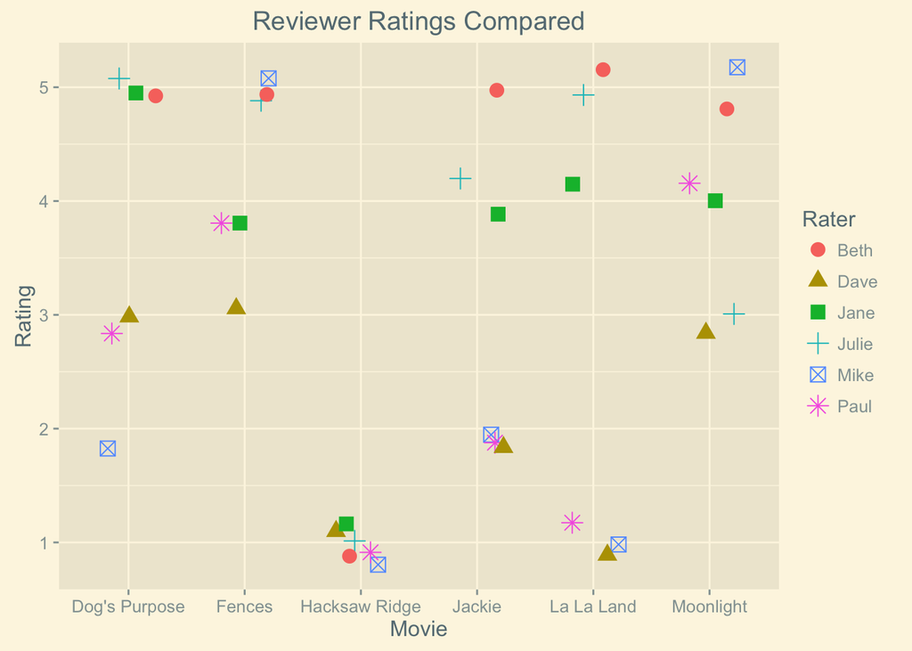

```r
# try some plots

# ggplot(results2, aes(x=Rater, fill=Rating)) + geom_density(alpha=.3)

ggplot(results2, aes(x=Movie, y=Rating, colour=Rater)) +
    geom_jitter(size = 3.5, aes(shape = Rater), width = .6, height = .5) +
    labs(title = "Reviewer Ratings Compared") +
    theme_solarized_2()
```

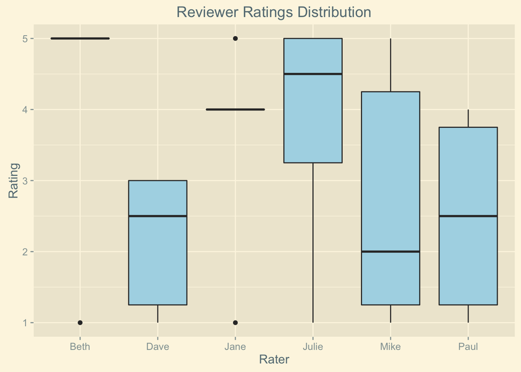

```r
ggplot(results2, aes(x=Rater, y=Rating)) + geom_boxplot(fill="lightblue") +
    guides(fill=FALSE) +
    labs(title = "Reviewer Ratings Distribution") +
    theme_solarized_2()
```